# Risk Factor Analysis

## Outcome Variable

**Outcome Variable:** haz

## Predictor Variables

**Intervention Variable:** hhwealth_quart

**Adjustment Set:**

unadjusted

## Stratifying Variables

The analysis was stratified on these variable(s):

- agecat
- studyid
- country

## Data Summary

| agecat | studyid | country | hhwealth_quart | n_cell | n |
| --- | --- | --- | --- | --- | --- |
| Birth | ki0047075b-MAL-ED | BANGLADESH | Wealth Q4 | 21 | 82 |
| Birth | ki0047075b-MAL-ED | BANGLADESH | Wealth Q1 | 21 | 82 |
| Birth | ki0047075b-MAL-ED | BANGLADESH | Wealth Q2 | 20 | 82 |
| Birth | ki0047075b-MAL-ED | BANGLADESH | Wealth Q3 | 20 | 82 |
| Birth | ki0047075b-MAL-ED | INDIA | Wealth Q4 | 12 | 55 |
| Birth | ki0047075b-MAL-ED | INDIA | Wealth Q1 | 17 | 55 |
| Birth | ki0047075b-MAL-ED | INDIA | Wealth Q2 | 15 | 55 |
| Birth | ki0047075b-MAL-ED | INDIA | Wealth Q3 | 11 | 55 |
| Birth | ki0047075b-MAL-ED | NEPAL | Wealth Q4 | 9 | 31 |
| Birth | ki0047075b-MAL-ED | NEPAL | Wealth Q1 | 8 | 31 |
| Birth | ki0047075b-MAL-ED | NEPAL | Wealth Q2 | 7 | 31 |
| Birth | ki0047075b-MAL-ED | NEPAL | Wealth Q3 | 7 | 31 |
| Birth | ki0047075b-MAL-ED | PERU | Wealth Q4 | 10 | 36 |
| Birth | ki0047075b-MAL-ED | PERU | Wealth Q1 | 9 | 36 |
| Birth | ki0047075b-MAL-ED | PERU | Wealth Q2 | 9 | 36 |
| Birth | ki0047075b-MAL-ED | PERU | Wealth Q3 | 8 | 36 |
| Birth | ki0047075b-MAL-ED | SOUTH AFRICA | Wealth Q4 | 15 | 61 |
| Birth | ki0047075b-MAL-ED | SOUTH AFRICA | Wealth Q1 | 16 | 61 |
| Birth | ki0047075b-MAL-ED | SOUTH AFRICA | Wealth Q2 | 14 | 61 |
| Birth | ki0047075b-MAL-ED | SOUTH AFRICA | Wealth Q3 | 16 | 61 |
| Birth | ki0047075b-MAL-ED | TANZANIA, UNITED REPUBLIC OF | Wealth Q4 | 5 | 23 |
| Birth | ki0047075b-MAL-ED | TANZANIA, UNITED REPUBLIC OF | Wealth Q1 | 6 | 23 |
| Birth | ki0047075b-MAL-ED | TANZANIA, UNITED REPUBLIC OF | Wealth Q2 | 7 | 23 |
| Birth | ki0047075b-MAL-ED | TANZANIA, UNITED REPUBLIC OF | Wealth Q3 | 5 | 23 |
| Birth | ki1000108-CMC-V-BCS-2002 | INDIA | Wealth Q4 | 31 | 90 |
| Birth | ki1000108-CMC-V-BCS-2002 | INDIA | Wealth Q1 | 14 | 90 |
| Birth | ki1000108-CMC-V-BCS-2002 | INDIA | Wealth Q2 | 20 | 90 |
| Birth | ki1000108-CMC-V-BCS-2002 | INDIA | Wealth Q3 | 25 | 90 |
| Birth | ki1000108-IRC | INDIA | Wealth Q4 | 91 | 388 |
| Birth | ki1000108-IRC | INDIA | Wealth Q1 | 98 | 388 |

[output cut: 158 more lines]

The following strata were considered:

- agecat: 24 months, studyid: ki0047075b-MAL-ED, country: BANGLADESH
- agecat: 24 months, studyid: ki0047075b-MAL-ED, country: INDIA
- agecat: 24 months, studyid: ki0047075b-MAL-ED, country: NEPAL
- agecat: 24 months, studyid: ki0047075b-MAL-ED, country: PERU
- agecat: 24 months, studyid: ki0047075b-MAL-ED, country: SOUTH AFRICA
- agecat: 24 months, studyid: ki0047075b-MAL-ED, country: TANZANIA, UNITED REPUBLIC OF
- agecat: 24 months, studyid: ki1000108-CMC-V-BCS-2002, country: INDIA
- agecat: 24 months, studyid: ki1000108-IRC, country: INDIA
- agecat: 24 months, studyid: ki1017093b-PROVIDE, country: BANGLADESH
- agecat: 24 months, studyid: ki1066203-TanzaniaChild2, country: TANZANIA, UNITED REPUBLIC OF
- agecat: 24 months, studyid: ki1113344-GMS-Nepal, country: NEPAL
- agecat: 24 months, studyid: ki1114097-CONTENT, country: PERU
- agecat: 24 months, studyid: ki1135781-COHORTS, country: GUATEMALA
- agecat: 24 months, studyid: ki1135781-COHORTS, country: PHILIPPINES
- agecat: 24 months, studyid: ki1148112-LCNI-5, country: MALAWI
- agecat: 24 months, studyid: kiGH5241-JiVitA-3, country: BANGLADESH
- agecat: 24 months, studyid: kiGH5241-JiVitA-4, country: BANGLADESH
- agecat: 6 months, studyid: ki0047075b-MAL-ED, country: BANGLADESH
- agecat: 6 months, studyid: ki0047075b-MAL-ED, country: INDIA
- agecat: 6 months, studyid: ki0047075b-MAL-ED, country: NEPAL
- agecat: 6 months, studyid: ki0047075b-MAL-ED, country: PERU
- agecat: 6 months, studyid: ki0047075b-MAL-ED, country: SOUTH AFRICA
- agecat: 6 months, studyid: ki0047075b-MAL-ED, country: TANZANIA, UNITED REPUBLIC OF
- agecat: 6 months, studyid: ki1000108-CMC-V-BCS-2002, country: INDIA
- agecat: 6 months, studyid: ki1000108-IRC, country: INDIA
- agecat: 6 months, studyid: ki1017093b-PROVIDE, country: BANGLADESH
- agecat: 6 months, studyid: ki1066203-TanzaniaChild2, country: TANZANIA, UNITED REPUBLIC OF
- agecat: 6 months, studyid: ki1113344-GMS-Nepal, country: NEPAL
- agecat: 6 months, studyid: ki1114097-CONTENT, country: PERU
- agecat: 6 months, studyid: ki1135781-COHORTS, country: GUATEMALA
- agecat: 6 months, studyid: ki1135781-COHORTS, country: PHILIPPINES
- agecat: 6 months, studyid: ki1148112-LCNI-5, country: MALAWI
- agecat: 6 months, studyid: kiGH5241-JiVitA-3, country: BANGLADESH
- agecat: 6 months, studyid: kiGH5241-JiVitA-4, country: BANGLADESH
- agecat: Birth, studyid: ki0047075b-MAL-ED, country: BANGLADESH
- agecat: Birth, studyid: ki0047075b-MAL-ED, country: INDIA
- agecat: Birth, studyid: ki0047075b-MAL-ED, country: NEPAL
- agecat: Birth, studyid: ki0047075b-MAL-ED, country: PERU
- agecat: Birth, studyid: ki0047075b-MAL-ED, country: SOUTH AFRICA
- agecat: Birth, studyid: ki0047075b-MAL-ED, country: TANZANIA, UNITED REPUBLIC OF
- agecat: Birth, studyid: ki1000108-CMC-V-BCS-2002, country: INDIA
- agecat: Birth, studyid: ki1000108-IRC, country: INDIA
- agecat: Birth, studyid: ki1114097-CONTENT, country: PERU
- agecat: Birth, studyid: ki1135781-COHORTS, country: GUATEMALA
- agecat: Birth, studyid: ki1135781-COHORTS, country: PHILIPPINES
- agecat: Birth, studyid: kiGH5241-JiVitA-3, country: BANGLADESH
- agecat: Birth, studyid: kiGH5241-JiVitA-4, country: BANGLADESH

### Dropped Strata

Some strata were dropped due to rare outcomes:

- agecat: Birth, studyid: ki1114097-CONTENT, country: PERU
- agecat: 24 months, studyid: ki1066203-TanzaniaChild2, country: TANZANIA, UNITED REPUBLIC OF

## Methods Detail

We’re interested in the causal parameters $E[Y_a]$ for all values of $a \in \mathcal{A}$. These parameters represent the mean outcome if, possibly contrary to fact, we intervened to set all units to have $A=a$. Under the randomization and positivity assumptions, these are identified by the statistical parameters $\psi_a=E_W[E_{Y|A,W}(Y|A=a,W)]$. In addition, we’re interested in the mean of $Y$, $E[Y]$ under no intervention (the observed mean). We will estimate these parameters by using SuperLearner to fit the relevant likelihood factors – $E_{Y|A,W}(Y|A=a,W)$ and $p(A=a|W)$, and then updating our likelihood fit using a joint TMLE.

For unadjusted analyses ($W=\{\}$), initial likelihoods were estimated using Lrnr_glm to estimate the simple $E(Y|A)$ and Lrnr_mean to estimate $p(A)$. For adjusted analyses, a small library containing Lrnr_glmnet, Lrnr_xgboost, and Lrnr_mean was used.

# Results Detail

## Results Plots

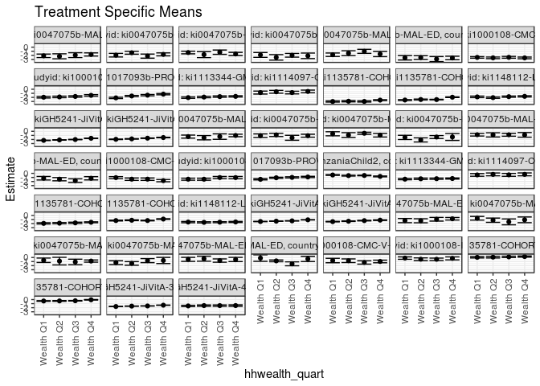

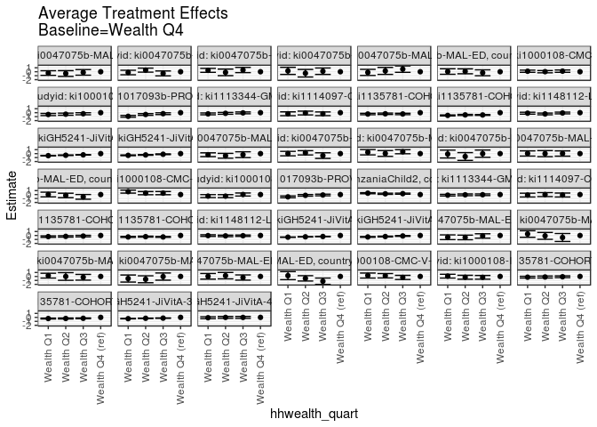

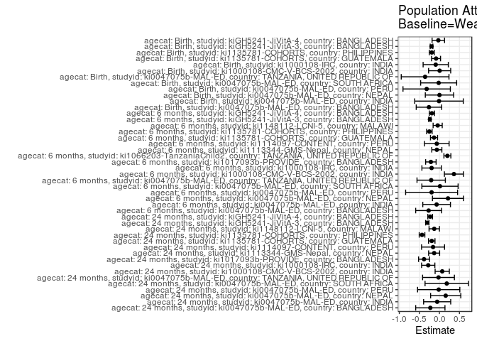

## Results Table

### Parameter: TSM

| agecat | studyid | country | intervention_level | baseline_level | estimate | ci_lower | ci_upper |
| --- | --- | --- | --- | --- | --- | --- | --- |
| Birth | ki0047075b-MAL-ED | BANGLADESH | Wealth Q4 | NA | -0.8204762 | -1.1357248 | -0.5052276 |
| Birth | ki0047075b-MAL-ED | BANGLADESH | Wealth Q1 | NA | -1.2623810 | -1.7741589 | -0.7506030 |
| Birth | ki0047075b-MAL-ED | BANGLADESH | Wealth Q2 | NA | -1.3090000 | -1.8003785 | -0.8176215 |
| Birth | ki0047075b-MAL-ED | BANGLADESH | Wealth Q3 | NA | -0.9375000 | -1.3885076 | -0.4864924 |
| Birth | ki0047075b-MAL-ED | INDIA | Wealth Q4 | NA | -1.0741667 | -1.7739887 | -0.3743446 |
| Birth | ki0047075b-MAL-ED | INDIA | Wealth Q1 | NA | -0.6929412 | -1.1427139 | -0.2431684 |
| Birth | ki0047075b-MAL-ED | INDIA | Wealth Q2 | NA | -1.1733333 | -1.6938207 | -0.6528460 |
| Birth | ki0047075b-MAL-ED | INDIA | Wealth Q3 | NA | -1.5781818 | -2.3009084 | -0.8554552 |
| Birth | ki0047075b-MAL-ED | NEPAL | Wealth Q4 | NA | -0.8788889 | -1.1434362 | -0.6143415 |
| Birth | ki0047075b-MAL-ED | NEPAL | Wealth Q1 | NA | -0.6800000 | -1.2219811 | -0.1380189 |
| Birth | ki0047075b-MAL-ED | NEPAL | Wealth Q2 | NA | -0.8871429 | -1.8180540 | 0.0437683 |
| Birth | ki0047075b-MAL-ED | NEPAL | Wealth Q3 | NA | -1.0900000 | -1.7651391 | -0.4148609 |
| Birth | ki0047075b-MAL-ED | PERU | Wealth Q4 | NA | -0.7340000 | -1.4942378 | 0.0262378 |
| Birth | ki0047075b-MAL-ED | PERU | Wealth Q1 | NA | -1.2622222 | -1.7251583 | -0.7992862 |
| Birth | ki0047075b-MAL-ED | PERU | Wealth Q2 | NA | -1.4455556 | -1.8778392 | -1.0132719 |
| Birth | ki0047075b-MAL-ED | PERU | Wealth Q3 | NA | -0.7675000 | -1.2626961 | -0.2723039 |
| Birth | ki0047075b-MAL-ED | SOUTH AFRICA | Wealth Q4 | NA | -0.4826667 | -0.9996637 | 0.0343304 |
| Birth | ki0047075b-MAL-ED | SOUTH AFRICA | Wealth Q1 | NA | -0.4537500 | -0.9468798 | 0.0393798 |
| Birth | ki0047075b-MAL-ED | SOUTH AFRICA | Wealth Q2 | NA | -0.2878571 | -0.9025410 | 0.3268267 |
| Birth | ki0047075b-MAL-ED | SOUTH AFRICA | Wealth Q3 | NA | -0.7525000 | -1.1615973 | -0.3434027 |
| Birth | ki0047075b-MAL-ED | TANZANIA, UNITED REPUBLIC OF | Wealth Q4 | NA | -0.3460000 | -0.9837324 | 0.2917324 |
| Birth | ki0047075b-MAL-ED | TANZANIA, UNITED REPUBLIC OF | Wealth Q1 | NA | -0.1416667 | -0.9344057 | 0.6510723 |
| Birth | ki0047075b-MAL-ED | TANZANIA, UNITED REPUBLIC OF | Wealth Q2 | NA | -0.8314286 | -1.0437617 | -0.6190954 |
| Birth | ki0047075b-MAL-ED | TANZANIA, UNITED REPUBLIC OF | Wealth Q3 | NA | -1.5520000 | -2.0330768 | -1.0709232 |
| Birth | ki1000108-CMC-V-BCS-2002 | INDIA | Wealth Q4 | NA | -0.9716129 | -1.2949901 | -0.6482357 |
| Birth | ki1000108-CMC-V-BCS-2002 | INDIA | Wealth Q1 | NA | -0.7442857 | -1.2874833 | -0.2010881 |
| Birth | ki1000108-CMC-V-BCS-2002 | INDIA | Wealth Q2 | NA | -0.7965000 | -1.2447030 | -0.3482970 |
| Birth | ki1000108-CMC-V-BCS-2002 | INDIA | Wealth Q3 | NA | -1.2168000 | -1.6234007 | -0.8101993 |
| Birth | ki1000108-IRC | INDIA | Wealth Q4 | NA | -0.2161538 | -0.5867320 | 0.1544243 |
| Birth | ki1000108-IRC | INDIA | Wealth Q1 | NA | -0.1436735 | -0.4437115 | 0.1563646 |

[output cut: 150 more lines]

### Parameter: E(Y)

| agecat | studyid | country | intervention_level | baseline_level | estimate | ci_lower | ci_upper |
| --- | --- | --- | --- | --- | --- | --- | --- |
| Birth | ki0047075b-MAL-ED | BANGLADESH | NA | NA | -1.0813415 | -1.3098662 | -0.8528167 |
| Birth | ki0047075b-MAL-ED | INDIA | NA | NA | -1.0841818 | -1.3853089 | -0.7830548 |
| Birth | ki0047075b-MAL-ED | NEPAL | NA | NA | -0.8770968 | -1.1861056 | -0.5680880 |
| Birth | ki0047075b-MAL-ED | PERU | NA | NA | -1.0513889 | -1.3551960 | -0.7475818 |
| Birth | ki0047075b-MAL-ED | SOUTH AFRICA | NA | NA | -0.5011475 | -0.7582104 | -0.2440847 |
| Birth | ki0047075b-MAL-ED | TANZANIA, UNITED REPUBLIC OF | NA | NA | -0.7026087 | -1.0554952 | -0.3497222 |
| Birth | ki1000108-CMC-V-BCS-2002 | INDIA | NA | NA | -0.9654444 | -1.1742112 | -0.7566777 |
| Birth | ki1000108-IRC | INDIA | NA | NA | -0.3080412 | -0.4687931 | -0.1472894 |
| Birth | ki1135781-COHORTS | GUATEMALA | NA | NA | 0.1452941 | 0.0610109 | 0.2295774 |
| Birth | ki1135781-COHORTS | PHILIPPINES | NA | NA | -0.2491505 | -0.2881717 | -0.2101294 |
| Birth | kiGH5241-JiVitA-3 | BANGLADESH | NA | NA | -1.5750490 | -1.5948262 | -1.5552718 |
| Birth | kiGH5241-JiVitA-4 | BANGLADESH | NA | NA | -1.4976642 | -1.5817349 | -1.4135935 |
| 6 months | ki0047075b-MAL-ED | BANGLADESH | NA | NA | -1.2886008 | -1.5330953 | -1.0441063 |
| 6 months | ki0047075b-MAL-ED | INDIA | NA | NA | -1.1499296 | -1.3858882 | -0.9139710 |
| 6 months | ki0047075b-MAL-ED | NEPAL | NA | NA | -0.7429762 | -0.9817457 | -0.5042067 |
| 6 months | ki0047075b-MAL-ED | PERU | NA | NA | -1.5801389 | -1.8994566 | -1.2608211 |
| 6 months | ki0047075b-MAL-ED | SOUTH AFRICA | NA | NA | -0.8550000 | -1.0838479 | -0.6261521 |
| 6 months | ki0047075b-MAL-ED | TANZANIA, UNITED REPUBLIC OF | NA | NA | -1.4104598 | -1.6281211 | -1.1927984 |
| 6 months | ki1000108-CMC-V-BCS-2002 | INDIA | NA | NA | -1.4234508 | -1.5645974 | -1.2823042 |
| 6 months | ki1000108-IRC | INDIA | NA | NA | -1.2344062 | -1.3658524 | -1.1029600 |
| 6 months | ki1017093b-PROVIDE | BANGLADESH | NA | NA | -1.0925674 | -1.1686395 | -1.0164954 |
| 6 months | ki1066203-TanzaniaChild2 | TANZANIA, UNITED REPUBLIC OF | NA | NA | -0.5442232 | -0.5932373 | -0.4952090 |
| 6 months | ki1113344-GMS-Nepal | NEPAL | NA | NA | -1.3321522 | -1.4103691 | -1.2539352 |
| 6 months | ki1114097-CONTENT | PERU | NA | NA | -0.3139217 | -0.4868486 | -0.1409948 |
| 6 months | ki1135781-COHORTS | GUATEMALA | NA | NA | -1.8112324 | -1.8807284 | -1.7417365 |
| 6 months | ki1135781-COHORTS | PHILIPPINES | NA | NA | -1.1405724 | -1.1824954 | -1.0986493 |
| 6 months | ki1148112-LCNI-5 | MALAWI | NA | NA | -1.6426961 | -1.7120603 | -1.5733318 |
| 6 months | kiGH5241-JiVitA-3 | BANGLADESH | NA | NA | -1.3132090 | -1.3363486 | -1.2900693 |
| 6 months | kiGH5241-JiVitA-4 | BANGLADESH | NA | NA | -1.3440477 | -1.3813060 | -1.3067894 |
| 24 months | ki0047075b-MAL-ED | BANGLADESH | NA | NA | -2.0155844 | -2.2679754 | -1.7631934 |
| 24 months | ki0047075b-MAL-ED | INDIA | NA | NA | -1.8247183 | -2.0459767 | -1.6034599 |
| 24 months | ki0047075b-MAL-ED | NEPAL | NA | NA | -1.5063095 | -1.7704452 | -1.2421738 |
| 24 months | ki0047075b-MAL-ED | PERU | NA | NA | -2.1384375 | -2.4638687 | -1.8130063 |
| 24 months | ki0047075b-MAL-ED | SOUTH AFRICA | NA | NA | -1.4993939 | -1.7838130 | -1.2149749 |
| 24 months | ki0047075b-MAL-ED | TANZANIA, UNITED REPUBLIC OF | NA | NA | -2.6744068 | -2.9325198 | -2.4162938 |
| 24 months | ki1000108-CMC-V-BCS-2002 | INDIA | NA | NA | -2.5593683 | -2.6601027 | -2.4586339 |
| 24 months | ki1000108-IRC | INDIA | NA | NA | -1.7824776 | -1.8765600 | -1.6883952 |
| 24 months | ki1017093b-PROVIDE | BANGLADESH | NA | NA | -1.5853993 | -1.6687810 | -1.5020176 |
| 24 months | ki1113344-GMS-Nepal | NEPAL | NA | NA | -1.8835905 | -1.9681499 | -1.7990312 |
| 24 months | ki1114097-CONTENT | PERU | NA | NA | -0.6962195 | -0.8674103 | -0.5250287 |
| 24 months | ki1135781-COHORTS | GUATEMALA | NA | NA | -2.8581407 | -2.9236747 | -2.7926066 |
| 24 months | ki1135781-COHORTS | PHILIPPINES | NA | NA | -2.3898650 | -2.4346888 | -2.3450412 |
| 24 months | ki1148112-LCNI-5 | MALAWI | NA | NA | -1.8714634 | -1.9528558 | -1.7900711 |
| 24 months | kiGH5241-JiVitA-3 | BANGLADESH | NA | NA | -2.0125560 | -2.0402683 | -1.9848436 |
| 24 months | kiGH5241-JiVitA-4 | BANGLADESH | NA | NA | -1.7578934 | -1.7933205 | -1.7224663 |

### Parameter: ATE

| agecat | studyid | country | intervention_level | baseline_level | estimate | ci_lower | ci_upper |
| --- | --- | --- | --- | --- | --- | --- | --- |
| Birth | ki0047075b-MAL-ED | BANGLADESH | Wealth Q4 | Wealth Q4 | 0.0000000 | 0.0000000 | 0.0000000 |
| Birth | ki0047075b-MAL-ED | BANGLADESH | Wealth Q1 | Wealth Q4 | -0.4419048 | -1.0429857 | 0.1591762 |
| Birth | ki0047075b-MAL-ED | BANGLADESH | Wealth Q2 | Wealth Q4 | -0.4885238 | -1.0723342 | 0.0952865 |
| Birth | ki0047075b-MAL-ED | BANGLADESH | Wealth Q3 | Wealth Q4 | -0.1170238 | -0.6672869 | 0.4332393 |
| Birth | ki0047075b-MAL-ED | INDIA | Wealth Q4 | Wealth Q4 | 0.0000000 | 0.0000000 | 0.0000000 |
| Birth | ki0047075b-MAL-ED | INDIA | Wealth Q1 | Wealth Q4 | 0.3812255 | -0.4506678 | 1.2131188 |
| Birth | ki0047075b-MAL-ED | INDIA | Wealth Q2 | Wealth Q4 | -0.0991667 | -0.9713238 | 0.7729904 |
| Birth | ki0047075b-MAL-ED | INDIA | Wealth Q3 | Wealth Q4 | -0.5040152 | -1.5100394 | 0.5020091 |
| Birth | ki0047075b-MAL-ED | NEPAL | Wealth Q4 | Wealth Q4 | 0.0000000 | 0.0000000 | 0.0000000 |
| Birth | ki0047075b-MAL-ED | NEPAL | Wealth Q1 | Wealth Q4 | 0.1988889 | -0.4042105 | 0.8019883 |
| Birth | ki0047075b-MAL-ED | NEPAL | Wealth Q2 | Wealth Q4 | -0.0082540 | -0.9760250 | 0.9595171 |
| Birth | ki0047075b-MAL-ED | NEPAL | Wealth Q3 | Wealth Q4 | -0.2111111 | -0.9362305 | 0.5140083 |
| Birth | ki0047075b-MAL-ED | PERU | Wealth Q4 | Wealth Q4 | 0.0000000 | 0.0000000 | 0.0000000 |
| Birth | ki0047075b-MAL-ED | PERU | Wealth Q1 | Wealth Q4 | -0.5282222 | -1.4183185 | 0.3618740 |
| Birth | ki0047075b-MAL-ED | PERU | Wealth Q2 | Wealth Q4 | -0.7115556 | -1.5861016 | 0.1629905 |
| Birth | ki0047075b-MAL-ED | PERU | Wealth Q3 | Wealth Q4 | -0.0335000 | -0.9407931 | 0.8737931 |
| Birth | ki0047075b-MAL-ED | SOUTH AFRICA | Wealth Q4 | Wealth Q4 | 0.0000000 | 0.0000000 | 0.0000000 |
| Birth | ki0047075b-MAL-ED | SOUTH AFRICA | Wealth Q1 | Wealth Q4 | 0.0289167 | -0.6855502 | 0.7433835 |
| Birth | ki0047075b-MAL-ED | SOUTH AFRICA | Wealth Q2 | Wealth Q4 | 0.1948095 | -0.6083855 | 0.9980045 |
| Birth | ki0047075b-MAL-ED | SOUTH AFRICA | Wealth Q3 | Wealth Q4 | -0.2698333 | -0.9291106 | 0.3894440 |
| Birth | ki0047075b-MAL-ED | TANZANIA, UNITED REPUBLIC OF | Wealth Q4 | Wealth Q4 | 0.0000000 | 0.0000000 | 0.0000000 |
| Birth | ki0047075b-MAL-ED | TANZANIA, UNITED REPUBLIC OF | Wealth Q1 | Wealth Q4 | 0.2043333 | -0.8130839 | 1.2217505 |
| Birth | ki0047075b-MAL-ED | TANZANIA, UNITED REPUBLIC OF | Wealth Q2 | Wealth Q4 | -0.4854286 | -1.1575804 | 0.1867232 |
| Birth | ki0047075b-MAL-ED | TANZANIA, UNITED REPUBLIC OF | Wealth Q3 | Wealth Q4 | -1.2060000 | -2.0048351 | -0.4071649 |
| Birth | ki1000108-CMC-V-BCS-2002 | INDIA | Wealth Q4 | Wealth Q4 | 0.0000000 | 0.0000000 | 0.0000000 |
| Birth | ki1000108-CMC-V-BCS-2002 | INDIA | Wealth Q1 | Wealth Q4 | 0.2273272 | -0.4048408 | 0.8594952 |
| Birth | ki1000108-CMC-V-BCS-2002 | INDIA | Wealth Q2 | Wealth Q4 | 0.1751129 | -0.3775703 | 0.7277961 |
| Birth | ki1000108-CMC-V-BCS-2002 | INDIA | Wealth Q3 | Wealth Q4 | -0.2451871 | -0.7647032 | 0.2743290 |
| Birth | ki1000108-IRC | INDIA | Wealth Q4 | Wealth Q4 | 0.0000000 | 0.0000000 | 0.0000000 |
| Birth | ki1000108-IRC | INDIA | Wealth Q1 | Wealth Q4 | 0.0724804 | -0.4043330 | 0.5492937 |

[output cut: 150 more lines]

### Parameter: PAR

| agecat | studyid | country | intervention_level | baseline_level | estimate | ci_lower | ci_upper |
| --- | --- | --- | --- | --- | --- | --- | --- |
| Birth | ki0047075b-MAL-ED | BANGLADESH | Wealth Q4 | NA | -0.2608653 | -0.5782017 | 0.0564712 |
| Birth | ki0047075b-MAL-ED | INDIA | Wealth Q4 | NA | -0.0100152 | -0.6155884 | 0.5955581 |
| Birth | ki0047075b-MAL-ED | NEPAL | Wealth Q4 | NA | 0.0017921 | -0.3515280 | 0.3551122 |
| Birth | ki0047075b-MAL-ED | PERU | Wealth Q4 | NA | -0.3173889 | -0.9082955 | 0.2735177 |
| Birth | ki0047075b-MAL-ED | SOUTH AFRICA | Wealth Q4 | NA | -0.0184809 | -0.4678306 | 0.4308688 |
| Birth | ki0047075b-MAL-ED | TANZANIA, UNITED REPUBLIC OF | Wealth Q4 | NA | -0.3566087 | -0.9519273 | 0.2387100 |
| Birth | ki1000108-CMC-V-BCS-2002 | INDIA | Wealth Q4 | NA | 0.0061685 | -0.2697252 | 0.2820621 |
| Birth | ki1000108-IRC | INDIA | Wealth Q4 | NA | -0.0918874 | -0.4061365 | 0.2223617 |
| Birth | ki1135781-COHORTS | GUATEMALA | Wealth Q4 | NA | -0.0832724 | -0.1951957 | 0.0286509 |
| Birth | ki1135781-COHORTS | PHILIPPINES | Wealth Q4 | NA | -0.1905163 | -0.2523107 | -0.1287220 |
| Birth | kiGH5241-JiVitA-3 | BANGLADESH | Wealth Q4 | NA | -0.1959114 | -0.2291383 | -0.1626846 |
| Birth | kiGH5241-JiVitA-4 | BANGLADESH | Wealth Q4 | NA | -0.0270085 | -0.1826200 | 0.1286030 |
| 6 months | ki0047075b-MAL-ED | BANGLADESH | Wealth Q4 | NA | -0.2686802 | -0.5917881 | 0.0544277 |
| 6 months | ki0047075b-MAL-ED | INDIA | Wealth Q4 | NA | -0.0692814 | -0.4145131 | 0.2759502 |
| 6 months | ki0047075b-MAL-ED | NEPAL | Wealth Q4 | NA | 0.2142965 | -0.1733414 | 0.6019344 |
| 6 months | ki0047075b-MAL-ED | PERU | Wealth Q4 | NA | -0.1941389 | -0.8422573 | 0.4539796 |
| 6 months | ki0047075b-MAL-ED | SOUTH AFRICA | Wealth Q4 | NA | 0.0146078 | -0.4372981 | 0.4665138 |
| 6 months | ki0047075b-MAL-ED | TANZANIA, UNITED REPUBLIC OF | Wealth Q4 | NA | -0.2050153 | -0.5587299 | 0.1486993 |
| 6 months | ki1000108-CMC-V-BCS-2002 | INDIA | Wealth Q4 | NA | 0.3622230 | 0.1243626 | 0.6000834 |
| 6 months | ki1000108-IRC | INDIA | Wealth Q4 | NA | -0.1943389 | -0.4364239 | 0.0477461 |
| 6 months | ki1017093b-PROVIDE | BANGLADESH | Wealth Q4 | NA | -0.2128255 | -0.3436566 | -0.0819944 |
| 6 months | ki1066203-TanzaniaChild2 | TANZANIA, UNITED REPUBLIC OF | Wealth Q4 | NA | 0.1995086 | 0.1131602 | 0.2858569 |
| 6 months | ki1113344-GMS-Nepal | NEPAL | Wealth Q4 | NA | -0.0641498 | -0.1896819 | 0.0613823 |
| 6 months | ki1114097-CONTENT | PERU | Wealth Q4 | NA | -0.0654826 | -0.3727333 | 0.2417681 |
| 6 months | ki1135781-COHORTS | GUATEMALA | Wealth Q4 | NA | -0.1336513 | -0.2218265 | -0.0454761 |
| 6 months | ki1135781-COHORTS | PHILIPPINES | Wealth Q4 | NA | -0.2502628 | -0.3186550 | -0.1818707 |
| 6 months | ki1148112-LCNI-5 | MALAWI | Wealth Q4 | NA | -0.0432030 | -0.1566832 | 0.0702772 |
| 6 months | kiGH5241-JiVitA-3 | BANGLADESH | Wealth Q4 | NA | -0.2371925 | -0.2669557 | -0.2074293 |
| 6 months | kiGH5241-JiVitA-4 | BANGLADESH | Wealth Q4 | NA | -0.1867801 | -0.2521204 | -0.1214398 |
| 24 months | ki0047075b-MAL-ED | BANGLADESH | Wealth Q4 | NA | -0.2262987 | -0.5913820 | 0.1387846 |
| 24 months | ki0047075b-MAL-ED | INDIA | Wealth Q4 | NA | -0.0555516 | -0.3936027 | 0.2824995 |
| 24 months | ki0047075b-MAL-ED | NEPAL | Wealth Q4 | NA | 0.1573268 | -0.2190976 | 0.5337513 |
| 24 months | ki0047075b-MAL-ED | PERU | Wealth Q4 | NA | -0.0174375 | -0.5447713 | 0.5098963 |
| 24 months | ki0047075b-MAL-ED | SOUTH AFRICA | Wealth Q4 | NA | 0.1834186 | -0.3580250 | 0.7248621 |
| 24 months | ki0047075b-MAL-ED | TANZANIA, UNITED REPUBLIC OF | Wealth Q4 | NA | -0.0224068 | -0.4188542 | 0.3740406 |
| 24 months | ki1000108-CMC-V-BCS-2002 | INDIA | Wealth Q4 | NA | 0.0704914 | -0.1066419 | 0.2476246 |
| 24 months | ki1000108-IRC | INDIA | Wealth Q4 | NA | -0.2787943 | -0.4442391 | -0.1133494 |
| 24 months | ki1017093b-PROVIDE | BANGLADESH | Wealth Q4 | NA | -0.3829634 | -0.5196256 | -0.2463012 |
| 24 months | ki1113344-GMS-Nepal | NEPAL | Wealth Q4 | NA | -0.1311627 | -0.2685001 | 0.0061747 |
| 24 months | ki1114097-CONTENT | PERU | Wealth Q4 | NA | -0.1579268 | -0.4448160 | 0.1289624 |
| 24 months | ki1135781-COHORTS | GUATEMALA | Wealth Q4 | NA | -0.1907213 | -0.2712297 | -0.1102129 |
| 24 months | ki1135781-COHORTS | PHILIPPINES | Wealth Q4 | NA | -0.4331644 | -0.5033395 | -0.3629894 |
| 24 months | ki1148112-LCNI-5 | MALAWI | Wealth Q4 | NA | -0.1287759 | -0.2580251 | 0.0004733 |
| 24 months | kiGH5241-JiVitA-3 | BANGLADESH | Wealth Q4 | NA | -0.3022153 | -0.3436439 | -0.2607867 |
| 24 months | kiGH5241-JiVitA-4 | BANGLADESH | Wealth Q4 | NA | -0.2299530 | -0.2886263 | -0.1712797 |